# Time series Analysis

## Loading packages

```r
knitr::opts_chunk$set(echo = TRUE)
library(MASS)
library(ggplot2)
library(tidyverse)
library(tseries)
```

## Data Preparation

We begin by loading our data and convert it to a time series using the `as.ts()` function. Then we plot our data.

### Import Dataset

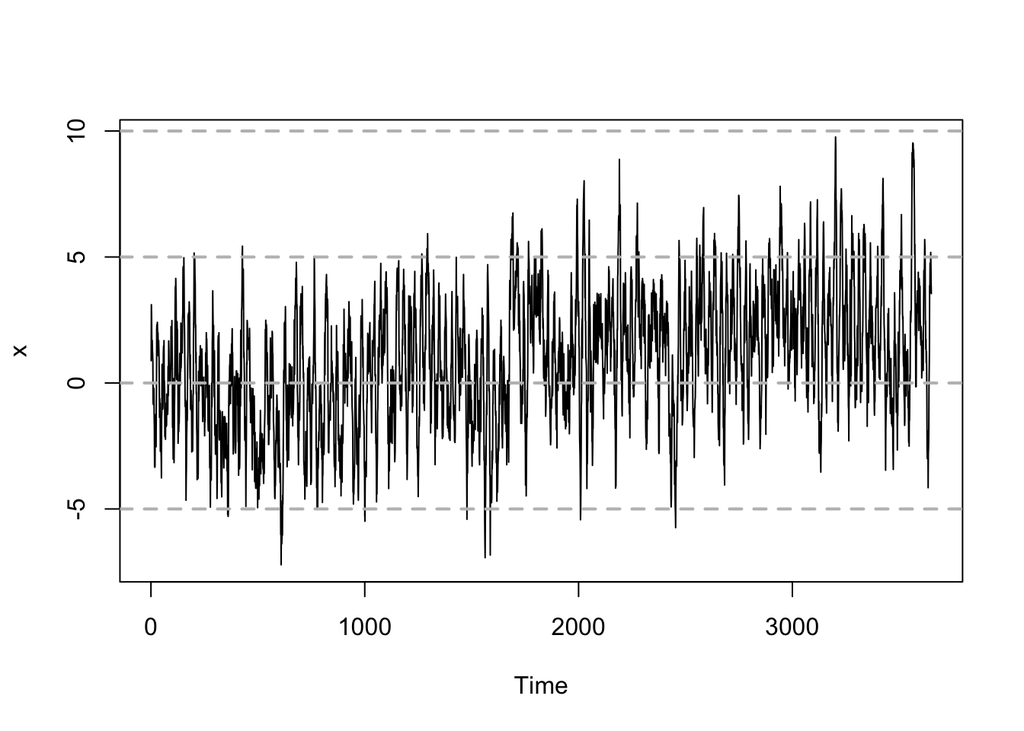

```r
#Load dataset
ts <- read_csv(filepath,show_col_types = FALSE)
##convert to time series data
tsData<-as.ts(ts)
#Plot time series
plot.ts(tsData)
grid(nx = NA,
     ny = NULL,
     lty = 2, col = "gray", lwd = 2)
```

It’s very hard to distinguish if there is a trend or seasonality by looking at the time series graph.We proceed by doing an autocorrelation analysis and looking at the resulting ACF plot.

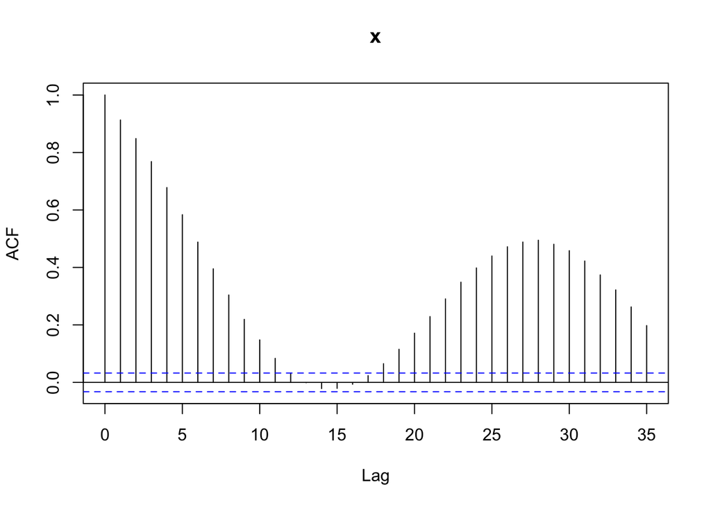

```r
#ACF plot
acf(tsData) # autocorrelation
```

We can observe that there is a trend and seasonal component in our time series.The slow decrease in the ACF as the lags increase is due to the trend component, while the periodic sinoid shape is due the seasonality.

## Parameters of linear trend component

We fit a linear model by regressing our series `ts` against time and plot the regression line. The upward trend becomes clearer in the new plot.

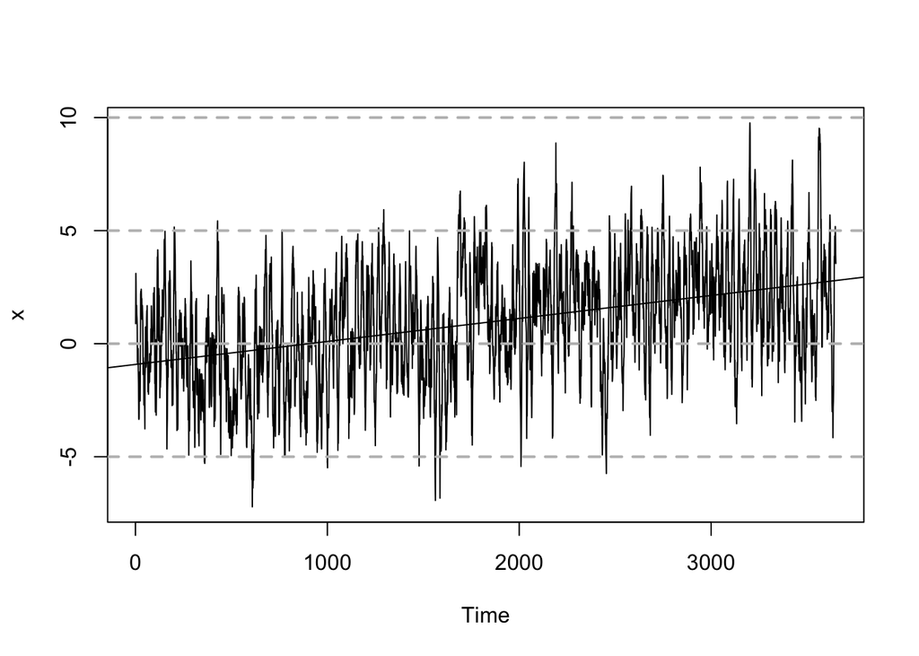

```r
##Linear regression
trModel<- lm(tsData ~ time(tsData))
##Plot time series with trending line
plot.ts(tsData)
grid(nx = NA,
     ny = NULL,
     lty = 2, col = "gray", lwd = 2)
abline(reg=trModel)
```

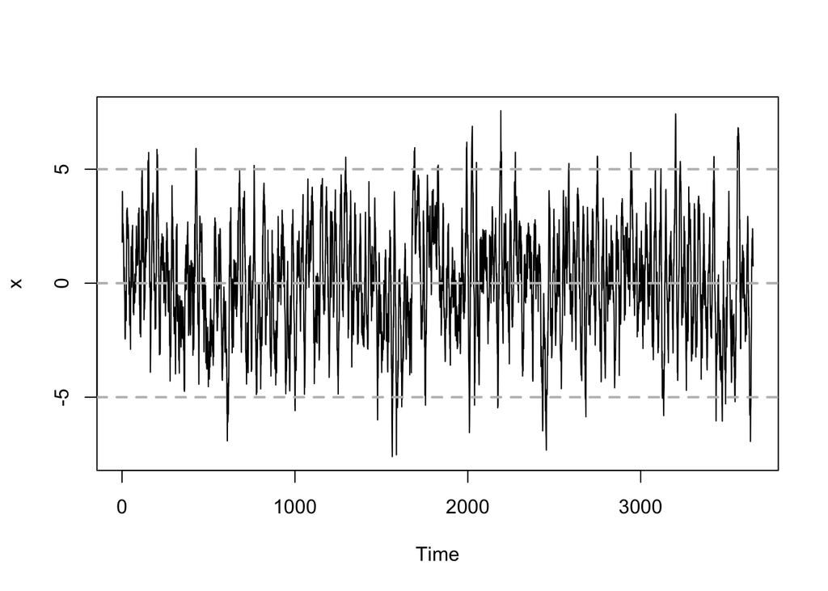

```r
##Removing the trend
trend <- trModel$fitted.values
d.data <- tsData - trend
##Plot the data
plot(d.data)
grid(nx = NA,
     ny = NULL,
     lty = 2, col = "gray", lwd = 2)
```

The parameters for the linear trend component are:

|  | x |
| --- | --- |
| (Intercept) | -0.9175246 |
| time(tsData) | 0.0010170 |

## Seasonal component

To interpret the seasonality and determine the frequency, we plot the ACF and PACF after removing the linear trend.

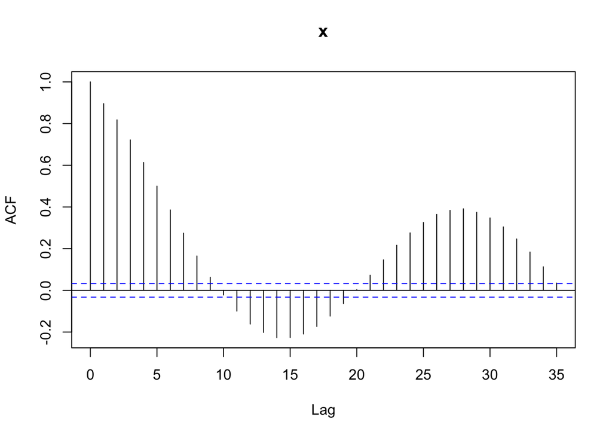

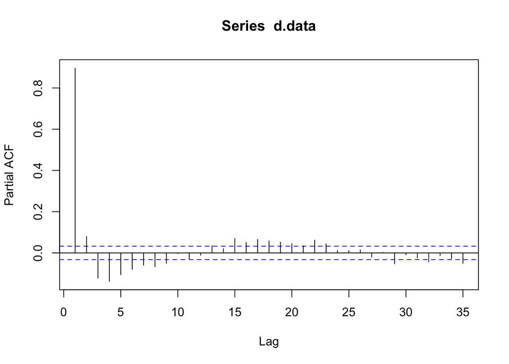

Looking at the ACF plot, we observe that there is a periodic trend with positive and negative spikes following each other. The highest peak occurs at lag 28 and there is another less significant peak at lag 14.The PACF is also kind of periodic and has some significant spikes from lag 3 to 7 and some small spikes coming after lag 15. Then, it cuts off after lag 24.

```r
spec<-spectrum(d.data)
```

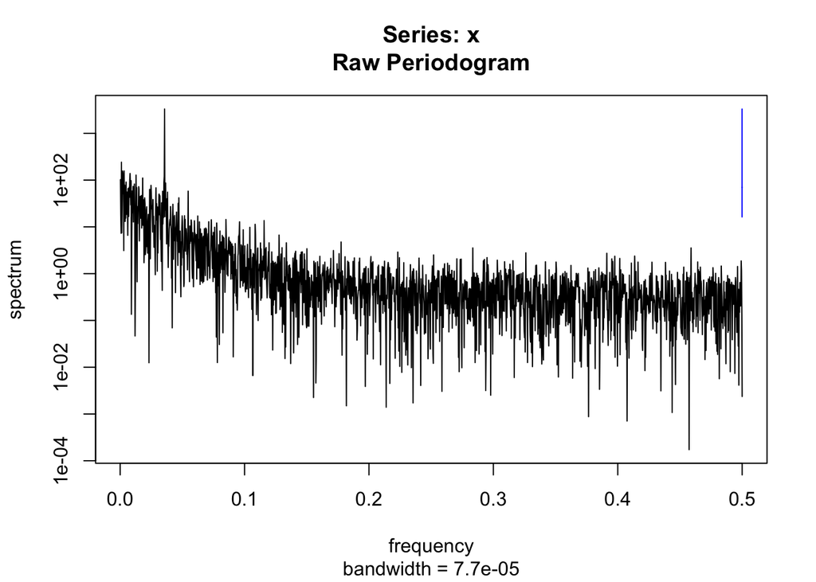

```r
spec.df <- data.frame(spec=spec$spec, freq=spec$freq)
frequency<-spec$freq[spec$spec==max(spec$spec)]
period<-round(1/frequency)
```

| frequency | period |
| --- | --- |
| 0.0357333 | 28 |

```r
diff.ts=diff(d.data, lag=T)  #lag difference
```

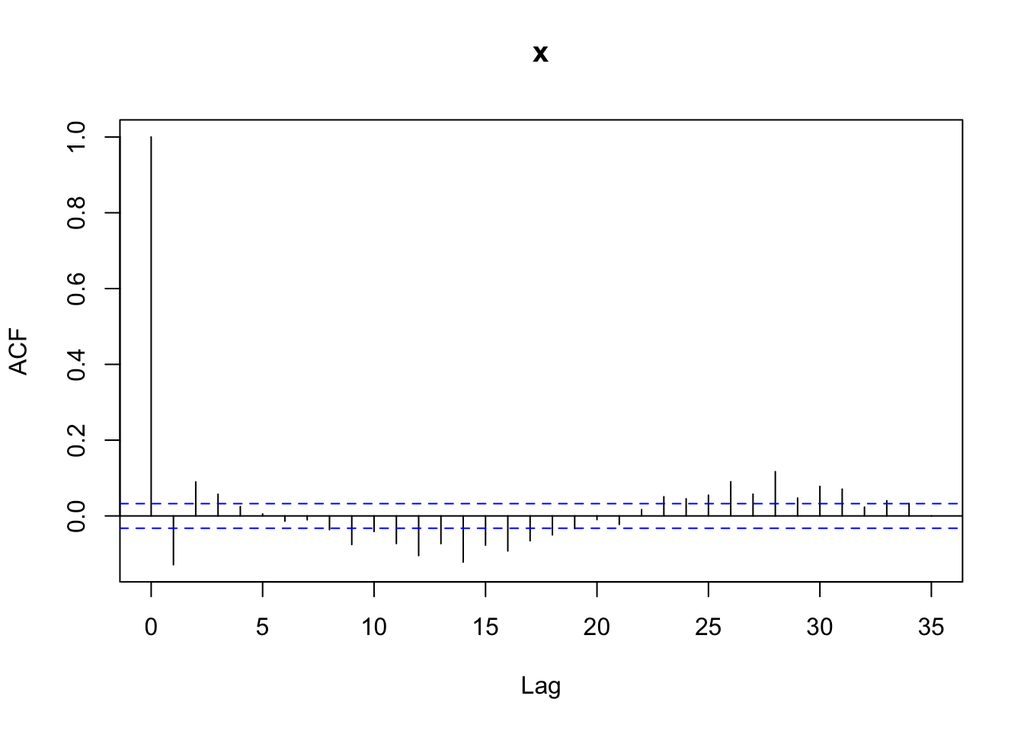

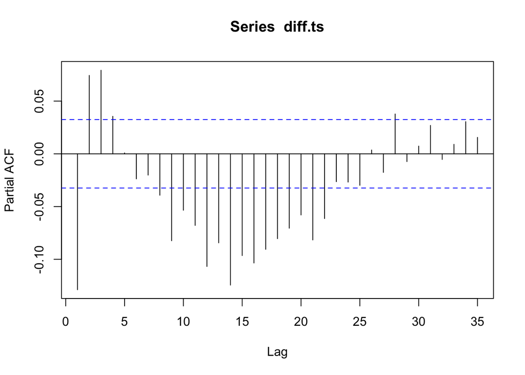

In the ACF, there are two significant spikes at lag 1 and 2 and a less significant at lag 3.Then we observe a decreasing trend in values, although there is a cluster of less significant negative and positive spikes around 14 and 28. This indicates a pattern around multiples of 14. The auto correlations in PACF are smaller in scale.There is a clear spike at lag 1, 2 and 3 and a cluster of negative spikes around lag 14. The spikes in the PACF around lag 14 and 28 combined with spikes around the same lags in the ACF indicates that a four-weekly seasonal component may exist. Moreover, the spikes in low lags in the PACF in combination with the decreasing trend of the ACF plot suggests a possible non seasonal AR.

## Dickey-Fuller test

After removing the trending and seasonal components, we’re going to test if the time series is stationary.We’re using a lag order of k=1,for the simple Dickey-Fuller test.

```r
#Augmented Dickey-Fuller Test
adf.test(diff.ts, k=1)
```

```
##
##  Augmented Dickey-Fuller Test
##
## data:  diff.ts
## Dickey-Fuller = -42.094, Lag order = 1, p-value = 0.01
## alternative hypothesis: stationary
```

We can observe that the p-value is (smaller than) 0.01, which suggests that we can reject the null hypothesis and conclude that the time series is stationary.However, we can’t claim that this is evidence in support of a particular alternative hypothesis (e.g. stationarity). The Dickey–Fuller test that we used above is used to test the null hypothesis, which is that a unit root is present in an auto regressive time series model.However, it can not detect other forms of nonstationarity as the alternative hypothesis is different depending on which version of the test is used.  
Our time series is clearly seasonal and more complicated than is captured by a simple AR(1) model. A more appropriate test would be the augmented Dickey Fuller test which was developed for general ARMA(p, q) models with unknown orders. This seems to be closer to our case and thus more appropriate.